# Predicting Heart Disease with R and Caret

Eduardo Abdala

## Introduction

Diagnosing disease and being able to take preventative measures is no easy task. When we talk about heart disease, we are usually told to eat healthier, exercise, and minimize stress. However, every person is different and a more targeted approach can improve patient outcomes. Clinicians and healthcare managers can leverage machine learning to improve patient care in all aspects of the service life-cycle.

## Problem

Diagnosing heart disease is not as easy as doing blood work and looking at an EKG. We are given a data set with de-identified patient records (detailed below) and we are tasked with creating a machine learning model that predicts if a patient has heart disease.

## Project Goals

Predict which patients are more likely to have heart disease, given a number of possible predictors. This tool would be used to support and streamline the decision making process for medical professionals. The following steps were taken:

1. Provide exploratory data analysis
2. Provide an overview of the data with visualizations
3. Preprocess the data set (partition, encode categorical features, and normalize)
4. Train and test different classification machine learning algorithms
5. Provide performance metrics and interpret the results.

## Description of the Data

This data set is taken from [kaggle.com](https://www.kaggle.com/) and sourced from the [UC Irvine Machine Learning Repository](https://archive.ics.uci.edu/ml/datasets/Heart+Disease). We have a data set of n = 303 with 13 features and one target column used to train a classifier machine learning algorithm.

The features are as follows:

1. age
2. sex (male = 1, female = 0)
3. cp = chest pain type (values 0-3)
4. trestbps = resting blood pressure (mm Hg)
5. chol = serum cholesterol (mg/dl)
6. fbs = fasting blood sugar (> 120 mg/dl)
7. restecg = resting ECG results (values 0-2)
8. thalach = max heart rate achieved
9. exang = exercised induced angina
10. oldpeak = ST depression induced by exercise
11. slope = slope of the peak exercise ST segment (values 0-2)
12. ca = number of major vessels colored by flouroscopy (values 0-4)
13. thal: 1 = normal, 2 = fixed defect, 3 = reversible defect
14. target = presence of heart disease (absent = FALSE, present = TRUE)

Analysis was done in RStudio using R v4.0.3. Package versions were managed with renv.

```r
dplyr::glimpse(heart)
```

```
Rows: 303
Columns: 14
$ age      <dbl> 63, 37, 41, 56, 57, 57, 56, 44, 52, 57, 54, 48, 49, 64, 58, 50, 58, 66, 43, 69, 59, 44, ~
$ sex      <fct> male, male, female, male, female, male, female, male, male, male, male, female, male, ma~
$ cp       <fct> 3, 2, 1, 1, 0, 0, 1, 1, 2, 2, 0, 2, 1, 3, 3, 2, 2, 3, 0, 3, 0, 2, 0, 2, 3, 1, 2, 2, 2, 2~
$ trestbps <dbl> 145, 130, 130, 120, 120, 140, 140, 120, 172, 150, 140, 130, 130, 110, 150, 120, 120, 150~
$ chol     <dbl> 233, 250, 204, 236, 354, 192, 294, 263, 199, 168, 239, 275, 266, 211, 283, 219, 340, 226~
$ fbs      <fct> 1, 0, 0, 0, 0, 0, 0, 0, 1, 0, 0, 0, 0, 0, 1, 0, 0, 0, 0, 0, 0, 0, 0, 1, 0, 0, 1, 0, 1, 1~
$ restecg  <fct> 0, 1, 0, 1, 1, 1, 0, 1, 1, 1, 1, 1, 1, 0, 0, 1, 1, 1, 1, 1, 1, 1, 1, 1, 1, 1, 1, 1, 0, 0~
$ thalach  <dbl> 150, 187, 172, 178, 163, 148, 153, 173, 162, 174, 160, 139, 171, 144, 162, 158, 172, 114~
$ exang    <fct> 0, 0, 0, 0, 1, 0, 0, 0, 0, 0, 0, 0, 0, 1, 0, 0, 0, 0, 0, 0, 0, 1, 0, 1, 1, 0, 0, 0, 0, 0~
$ oldpeak  <dbl> 2.3, 3.5, 1.4, 0.8, 0.6, 0.4, 1.3, 0.0, 0.5, 1.6, 1.2, 0.2, 0.6, 1.8, 1.0, 1.6, 0.0, 2.6~
$ slope    <fct> 0, 0, 2, 2, 2, 1, 1, 2, 2, 2, 2, 2, 2, 1, 2, 1, 2, 0, 2, 2, 1, 2, 2, 1, 2, 2, 2, 2, 2, 0~
$ ca       <fct> 0, 0, 0, 0, 0, 0, 0, 0, 0, 0, 0, 0, 0, 0, 0, 0, 0, 0, 0, 2, 0, 0, 0, 0, 0, 2, 0, 0, 1, 0~
$ thal     <fct> 1, 2, 2, 2, 2, 1, 2, 3, 3, 2, 2, 2, 2, 2, 2, 2, 2, 2, 2, 2, 3, 2, 2, 2, 3, 2, 2, 2, 2, 2~
$ target   <fct> positive, positive, positive, positive, positive, positive, positive, positive, positive~
```

Below is an overview of our data set. This view is helpful for us to see feature distributions, class imbalances in our target column (which can influence what we do in preprocessing and algorithm selection), and get a feel for variable distributions. I renamed the target and sex columns to make them easier to interpret. Instead of 0 and 1, words are used (negative, positive, male, female).

```r
summary(heart)
```

```
      age            sex      cp         trestbps          chol       fbs     restecg    thalach
 Min.   :29.00   female: 96   0:143   Min.   : 94.0   Min.   :126.0   1: 45   0:147   Min.   : 71.0
 1st Qu.:47.50   male  :207   1: 50   1st Qu.:120.0   1st Qu.:211.0   0:258   1:152   1st Qu.:133.5
 Median :55.00                2: 87   Median :130.0   Median :240.0           2:  4   Median :153.0
 Mean   :54.37                3: 23   Mean   :131.6   Mean   :246.3                   Mean   :149.6
 3rd Qu.:61.00                        3rd Qu.:140.0   3rd Qu.:274.5                   3rd Qu.:166.0
 Max.   :77.00                        Max.   :200.0   Max.   :564.0                   Max.   :202.0
 exang      oldpeak     slope   ca      thal         target
 0:204   Min.   :0.00   0: 21   0:175   0:  2   negative:138
 1: 99   1st Qu.:0.00   1:140   2: 38   1: 18   positive:165
         Median :0.80   2:142   1: 65   2:166
         Mean   :1.04           3: 20   3:117
         3rd Qu.:1.60           4:  5
         Max.   :6.20
```

```r
# clean with dplyr
heart %>%
  count(target, sex)
```

| target | sex | n |
| --- | --- | --- |
| negative | female | 24 |
| negative | male | 114 |
| positive | female | 72 |
| positive | male | 93 |

```
[1] Percent of people with heart disease: 54.46%
[1] Percent of people without heart disease: 45.54%
[1] Percent of men with heart disease: 44.93%
[1] Percent of women with heart disease: 75%
[1] Overall percent male in sample: 68.32%
[1] Overall percent female in sample: 31.68%
```

Here, we examine the difference in mean values for the continuous variables to see if any stand out (chol, thalach, and oldpeak). We also see that people with heart disease were usually a few years younger. We usually think that you are more susceptible to heart disease as you get older. While there are differences in means in this sample, we do not know if these are due to chance. Hypothesis testing would allow us to see if there is evidence to support a real difference between the two groups. I explored if these changes were significant enough in another paper in this repository.

```r
meanby_target <- heart %>%
                  group_by(target) %>%
                  summarize_at(c("age", "trestbps", "chol", "thalach", "oldpeak"),mean)
meanby_target
```

| target | age | trestbps | chol | thalach | oldpeak |
| --- | --- | --- | --- | --- | --- |
| negative | 56.60145 | 134.3986 | 251.0870 | 139.1014 | 1.5855072 |
| positive | 52.49697 | 129.3030 | 242.2303 | 158.4667 | 0.5830303 |

We could even separate the data by sex to tell us if there are differences between males and females in the mean values above for our continuous variables.

```r
meanby_targetsex <- heart %>%
  group_by(target,sex) %>%
  summarize_at(c("age", "trestbps", "chol", "thalach", "oldpeak"),mean) %>%
  arrange(sex)

meanby_targetsex
```

| target | sex | age | trestbps | chol | thalach | oldpeak |
| --- | --- | --- | --- | --- | --- | --- |
| negative | female | 59.04167 | 146.1250 | 274.9583 | 142.4167 | 1.8416667 |
| positive | female | 54.55556 | 128.7361 | 256.7500 | 154.0278 | 0.5541667 |
| negative | male | 56.08772 | 131.9298 | 246.0614 | 138.4035 | 1.5315789 |
| positive | male | 50.90323 | 129.7419 | 230.9892 | 161.9032 | 0.6053763 |

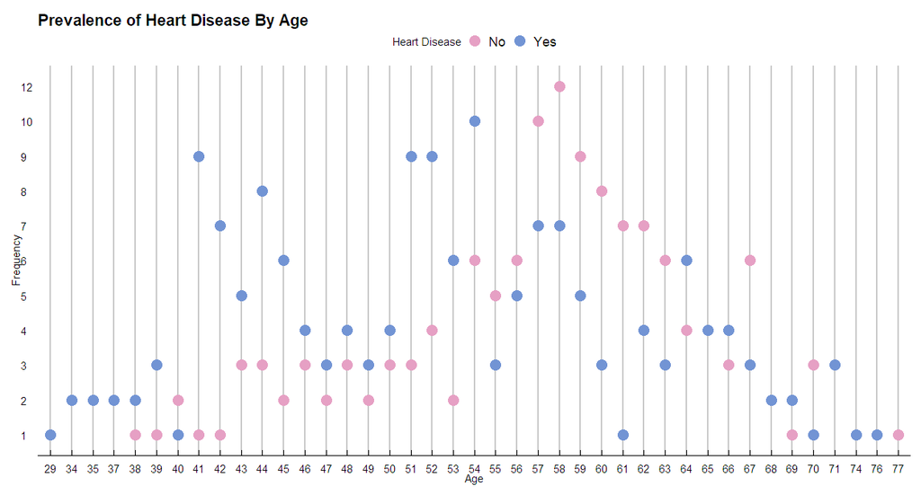

The graph above visualizes the difference in age distributions between the heart disease group and the healthy group. We again see that a number of patients with heart disease were younger, which goes against what we normally think. We can hypothesize from this graph that age will be less useful in predicting heart disease, though we will be able to visualize variable importance below.

## Preprocessing

```r
#partition, encode, normalize both train and test sets

set.seed(100)
trainIndex <- createDataPartition(heart$target, p = .70, list = FALSE)
trainingSet <- heart[trainIndex,]
testSet<- heart[-trainIndex,]

dummies <- dummyVars(target ~ ., data = trainingSet)
trainingSetX <- as.data.frame(predict(dummies, newdata = trainingSet))
```

```
variable 'target' is not a factor
```

```r
normModel <- preProcess(trainingSetX, method = "center")
trainingSetX <- predict(normModel, newdata = trainingSetX)
head(trainingSetX)
```

|  | age | sex.female | sex.male | cp.0 | cp.1 | cp.2 | cp.3 | trestbps | chol | fbs.1 | fbs.0 | restecg.0 | restecg.1 | restecg.2 | thalach | exang.0 | exang.1 | oldpeak | slope.0 | slope.1 | slope.2 | ca.0 | ca.2 | ca.1 | ca.3 | ca.4 | thal.0 | thal.1 | thal.2 | … |
| --- | --- | --- | --- | --- | --- | --- | --- | --- | --- | --- | --- | --- | --- | --- | --- | --- | --- | --- | --- | --- | --- | --- | --- | --- | --- | --- | --- | --- | --- | --- |
| 1 | 9.1830986 | -0.314554 | 0.314554 | -0.4788732 | -0.1737089 | -0.2816901 | 0.9342723 | 14.1126761 | -12.549296 | 0.8638498 | -0.8638498 | 0.5399061 | -0.5258216 | -0.01408451 | -0.5211268 | 0.3380282 | -0.3380282 | 1.2441315 | 0.9342723 | -0.4460094 | -0.4882629 | 0.3896714 | -0.1126761 | -0.1971831 | -0.06103286 | -0.01877934 | -0.004694836 | 0.93896714 | -0.5258216 | … |
| 2 | -12.8169014 | 0.685446 | -0.685446 | -0.4788732 | 0.8262911 | -0.2816901 | -0.0657277 | -0.8873239 | -41.549296 | -0.1361502 | 0.1361502 | 0.5399061 | -0.5258216 | -0.01408451 | 21.4788732 | 0.3380282 | -0.3380282 | 0.3441315 | -0.0657277 | -0.4460094 | 0.5117371 | 0.3896714 | -0.1126761 | -0.1971831 | -0.06103286 | -0.01877934 | -0.004694836 | -0.06103286 | 0.4741784 | … |
| 3 | 3.1830986 | 0.685446 | -0.685446 | 0.5211268 | -0.1737089 | -0.2816901 | -0.0657277 | -10.8873239 | 108.450704 | -0.1361502 | 0.1361502 | -0.4600939 | 0.4741784 | -0.01408451 | 12.4788732 | -0.6619718 | 0.6619718 | -0.4558685 | -0.0657277 | -0.4460094 | 0.5117371 | 0.3896714 | -0.1126761 | -0.1971831 | -0.06103286 | -0.01877934 | -0.004694836 | -0.06103286 | 0.4741784 | … |
| 4 | 2.1830986 | 0.685446 | -0.685446 | -0.4788732 | 0.8262911 | -0.2816901 | -0.0657277 | 9.1126761 | 48.450704 | -0.1361502 | 0.1361502 | 0.5399061 | -0.5258216 | -0.01408451 | 2.4788732 | 0.3380282 | -0.3380282 | 0.2441315 | -0.0657277 | 0.5539906 | -0.4882629 | 0.3896714 | -0.1126761 | -0.1971831 | -0.06103286 | -0.01877934 | -0.004694836 | -0.06103286 | 0.4741784 | … |
| 5 | -9.8169014 | -0.314554 | 0.314554 | -0.4788732 | 0.8262911 | -0.2816901 | -0.0657277 | -10.8873239 | 17.450704 | -0.1361502 | 0.1361502 | -0.4600939 | 0.4741784 | -0.01408451 | 22.4788732 | 0.3380282 | -0.3380282 | -1.0558685 | -0.0657277 | -0.4460094 | 0.5117371 | 0.3896714 | -0.1126761 | -0.1971831 | -0.06103286 | -0.01877934 | -0.004694836 | -0.06103286 | -0.5258216 | … |
| 6 | 0.1830986 | -0.314554 | 0.314554 | 0.5211268 | -0.1737089 | -0.2816901 | -0.0657277 | 9.1126761 | -6.549296 | -0.1361502 | 0.1361502 | -0.4600939 | 0.4741784 | -0.01408451 | 9.4788732 | 0.3380282 | -0.3380282 | 0.1441315 | -0.0657277 | -0.4460094 | 0.5117371 | 0.3896714 | -0.1126761 | -0.1971831 | -0.06103286 | -0.01877934 | -0.004694836 | -0.06103286 | 0.4741784 | … |

```r
trainingSet <- cbind(trainingSet$target, trainingSetX)
names(trainingSet)[1] <- "target"

testSet_dummy <- predict(dummies, testSet)
```

```
variable 'target' is not a factor
```

```r
testSet_norm <- predict(normModel, testSet_dummy)
testSet_norm <- data.frame(testSet_norm)
testSet <- cbind(testSet$target, testSet_norm)
names(testSet) <- names(trainingSet)
```